# Multivariate Analysis

Next, work up and visualize the alpha diversity data to see if there are any trends.

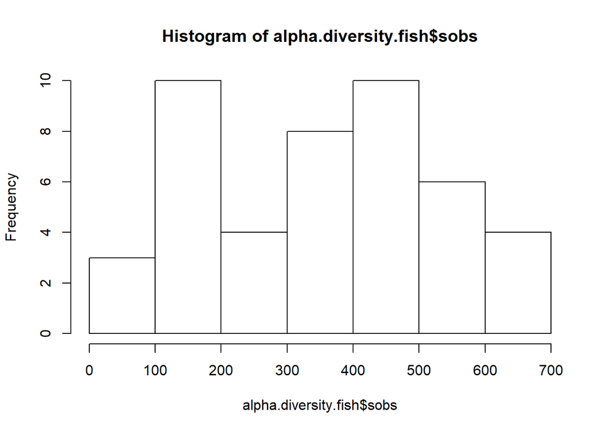

```r
#Combine metadata df with respective apha diversity df.
alpha.diversity.fish=cbind(alpha.diversity.fish,metadata.fish.unifrac)
alpha.diversity.fish.F4.F8=cbind(alpha.diversity.fish.F4.F8,metadata.fish.F4.F8.unifrac)

#make a function to calculate standard error
stderror=function(x) {
  se=sd(x)/sqrt(length(x))
  return(se)
}

#Calculate means and SE of the sobs and shannon evenness alpha diversity metrics for each Gut_Section and save as a df
alpha.diversity.mean.gut_Zone=aggregate(alpha.diversity.fish$sobs,by=list(alpha.diversity.fish$Gut_Zone),FUN=mean)$x #aggregate (mean) sobs by Gut_Section, save in new df.
alpha.diversity.mean.gut_Zone=as.data.frame(alpha.diversity.mean.gut_Zone)
colnames(alpha.diversity.mean.gut_Zone)[1]="sobs" #rename column 1 to sobs.
alpha.diversity.mean.gut_Zone$SE_sobs=aggregate(alpha.diversity.fish$sobs,by=list(alpha.diversity.fish$Gut_Zone),FUN=stderror)$x #aggregate (stderror) sobs by Gut_Zone, save as a new column in df.
#repeat this for shannoneven
alpha.diversity.mean.gut_Zone$shannoneven=aggregate(alpha.diversity.fish$shannoneven,by=list(alpha.diversity.fish$Gut_Zone),FUN=mean)$x
alpha.diversity.mean.gut_Zone$SE_shannoneven=aggregate(alpha.diversity.fish$shannoneven,by=list(alpha.diversity.fish$Gut_Zone),FUN=stderror)$x
#now add in a Gut_Zone column
alpha.diversity.mean.gut_Zone$Gut_Zone=aggregate(alpha.diversity.fish$shannoneven,by=list(alpha.diversity.fish$Gut_Zone),FUN=stderror)$Group.1

#Model the alpha diversity (sobs and shannoneven) metrics using mixed models with Gut_Section and Fish_Species as fixed effects and Fish_ID as a random effect.
#First, check to see that the sobs and shannoneven data are normal
hist(alpha.diversity.fish$sobs) #asses normality of sobs data
```

```r
shapiro.test(alpha.diversity.fish$sobs)
```

```
##
##  Shapiro-Wilk normality test
##
## data:  alpha.diversity.fish$sobs
## W = 0.95377, p-value = 0.07064
```

The sobs data appearto be normal.

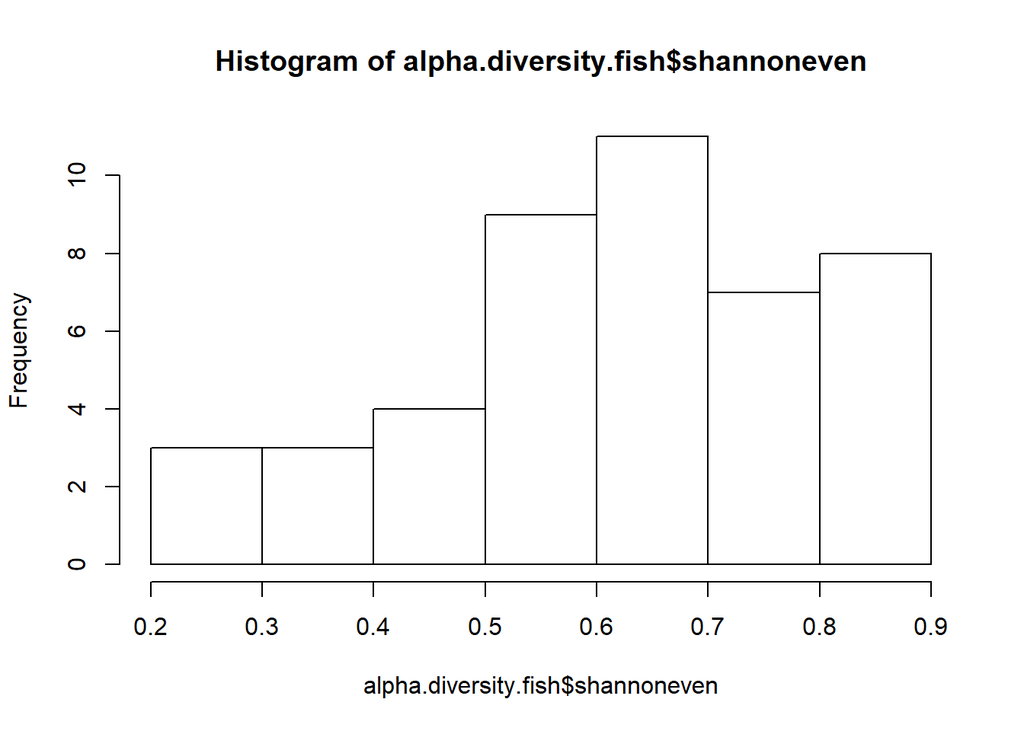

```r
hist(alpha.diversity.fish$shannoneven) #asses normality of shannoneven data
```

```r
shapiro.test(alpha.diversity.fish$shannoneven)
```

```
##
##  Shapiro-Wilk normality test
##
## data:  alpha.diversity.fish$shannoneven
## W = 0.95144, p-value = 0.05762
```

The shannoneven data appear to be (barely) normal. Thus I will not transform either the sobs or shannoneven data prior to running the mixed models.

```r
#use the GI culled data!
#Model the sobs data in response to Gut_seciton, fish species, and fish ID
adiv.mod.gut.nested.sobs=lmer(sobs~Gut_Zone/Gut_SubSection+Species+(1|Fish_Number),data=alpha.diversity.fish)
```

```
## fixed-effect model matrix is rank deficient so dropping 20 columns / coefficients
```

```r
summary(adiv.mod.gut.nested.sobs) #Note that including the Fish_Number ranef yields a singularity error regardless of species
```

```
## Linear mixed model fit by REML. t-tests use Satterthwaite's method [
## lmerModLmerTest]
## Formula: sobs ~ Gut_Zone/Gut_SubSection + Species + (1 | Fish_Number)
##    Data: alpha.diversity.fish
##
## REML criterion at convergence: 412.2
##
## Scaled residuals:
##      Min       1Q   Median       3Q      Max
## -2.15705 -0.48781 -0.00859  0.55618  1.56060
##
## Random effects:
##  Groups      Name        Variance Std.Dev.
##  Fish_Number (Intercept)   59.84   7.736
##  Residual                8805.27  93.836
## Number of obs: 45, groups:  Fish_Number, 8
##
## Fixed effects:
##                               Estimate Std. Error       df t value Pr(>|t|)
## (Intercept)                    512.365     48.925   25.031  10.473 1.24e-10 ***
## Gut_ZoneGI                    -464.417     66.755   32.758  -6.957 6.19e-08 ***
## Gut_ZoneHG                    -166.417     66.755   32.758  -2.493  0.01790 *
## SpeciesKyphosus hawaiiensis     46.989     44.616    6.786   1.053  0.32831
## SpeciesKyphosus vaigiensis      63.634     37.838    6.083   1.682  0.14294
## Gut_ZoneGI:Gut_SubSectionGI_1   82.783     73.088   32.744   1.133  0.26559
## Gut_ZoneGI:Gut_SubSectionGI_2   27.744     73.150   32.790   0.379  0.70693
## Gut_ZoneGI:Gut_SubSectionGI_3   89.781     69.206   32.343   1.297  0.20370
## Gut_ZoneGI:Gut_SubSectionGI_4  239.381     69.206   32.343   3.459  0.00154 **
## Gut_ZoneHG:Gut_SubSectionHG_1  118.581     69.206   32.343   1.713  0.09620 .
## Gut_ZoneHG:Gut_SubSectionHG_2  101.181     69.206   32.343   1.462  0.15338
## Gut_ZoneHG:Gut_SubSectionHG_3   50.981     69.206   32.343   0.737  0.46664
## ---
## Signif. codes:  0 '***' 0.001 '**' 0.01 '*' 0.05 '.' 0.1 ' ' 1
##
## Correlation of Fixed Effects:
##                (Intr) Gt_ZGI Gt_ZHG SpcsKh SpcsKv G_ZGI:G_SSGI_1 G_ZGI:G_SSGI_2
## Gut_ZoneGI     -0.502
## Gut_ZoneHG     -0.502  0.341
## SpcsKyphssh    -0.539  0.056  0.056
## SpcsKyphssv    -0.571  0.091  0.091  0.616
## G_ZGI:G_SSGI_1  0.014 -0.614 -0.012  0.068 -0.089
## G_ZGI:G_SSGI_2  0.094 -0.622 -0.021 -0.079 -0.179  0.577
## G_ZGI:G_SSGI_3  0.037 -0.648 -0.013 -0.003 -0.091  0.605          0.605
## G_ZGI:G_SSGI_4  0.037 -0.648 -0.013 -0.003 -0.091  0.605          0.605
## G_ZHG:G_SSHG_1  0.037 -0.013 -0.648 -0.003 -0.091  0.025          0.025
## G_ZHG:G_SSHG_2  0.037 -0.013 -0.648 -0.003 -0.091  0.025          0.025
## G_ZHG:G_SSHG_3  0.037 -0.013 -0.648 -0.003 -0.091  0.025          0.025
##                G_ZGI:G_SSGI_3 G_ZGI:G_SSGI_4 G_ZHG:G_SSHG_1 G_ZHG:G_SSHG_2
## Gut_ZoneGI
## Gut_ZoneHG
## SpcsKyphssh
## SpcsKyphssv
## G_ZGI:G_SSGI_1
## G_ZGI:G_SSGI_2
## G_ZGI:G_SSGI_3
## G_ZGI:G_SSGI_4  0.632
## G_ZHG:G_SSHG_1  0.019          0.019
## G_ZHG:G_SSHG_2  0.019          0.019          0.632
## G_ZHG:G_SSHG_3  0.019          0.019          0.632          0.632
## fit warnings:
## fixed-effect model matrix is rank deficient so dropping 20 columns / coefficients
```

```r
anova(adiv.mod.gut.nested.sobs,ddf="Kenward-Roger") #Gut_Section is significant
```

```
## Missing cells for: Gut_ZoneGI:Gut_SubSectionST, Gut_ZoneHG:Gut_SubSectionST, Gut_ZoneST:Gut_SubSectionGI_1, Gut_ZoneHG:Gut_SubSectionGI_1, Gut_ZoneST:Gut_SubSectionGI_2, Gut_ZoneHG:Gut_SubSectionGI_2, Gut_ZoneST:Gut_SubSectionGI_3, Gut_ZoneHG:Gut_SubSectionGI_3, Gut_ZoneST:Gut_SubSectionGI_4, Gut…
## Interpret type III hypotheses with care.
```

```
## Type III Analysis of Variance Table with Kenward-Roger's method
##                         Sum Sq Mean Sq NumDF   DenDF F value    Pr(>F)
## Gut_Zone                421653  210826     2 31.5437 23.9166 4.775e-07 ***
## Species                  23497   11749     2  4.7446  1.3311   0.34763
## Gut_Zone:Gut_SubSection 176915   25274     7 29.5832  2.8473   0.02139 *
## ---
## Signif. codes:  0 '***' 0.001 '**' 0.01 '*' 0.05 '.' 0.1 ' ' 1
```

```r
lsmeans(adiv.mod.gut.nested.sobs, pairwise ~ Gut_Zone, adjust="tukey") #HG and ST are not significantly different from each other, both are significantly different from GI.
```

```
## NOTE: A nesting structure was detected in the fitted model:
##     Gut_SubSection %in% Gut_Zone
```

```
## NOTE: Results may be misleading due to involvement in interactions
```

```
## $lsmeans
##  Gut_Zone lsmean   SE   df lower.CL upper.CL
##  ST          549 39.1 32.5      470      629
##  GI          173 22.7 15.2      124      221
##  HG          451 23.7 18.2      401      500
##
## Results are averaged over the levels of: Species, Gut_SubSection
## Degrees-of-freedom method: kenward-roger
## Confidence level used: 0.95
##
## $contrasts
##  contrast estimate   SE   df t.ratio p.value
##  ST - GI     376.5 44.2 30.8  8.513  <.0001
##  ST - HG      98.7 45.0 30.7  2.192  0.0885
##  GI - HG    -277.7 30.9 29.4 -8.998  <.0001
##
## Results are averaged over the levels of: Species, Gut_SubSection
## Degrees-of-freedom method: kenward-roger
## P value adjustment: tukey method for comparing a family of 3 estimates
```

```r
#Model the shannoneven data in response to Gut_seciton, fish species, and fish ID
adiv.mod.gut.Zone.shannoneven=lmer(shannoneven~Gut_Zone+Species+(1|Fish_Number),data=alpha.diversity.fish)
summary(adiv.mod.gut.Zone.shannoneven)
```

```
## Linear mixed model fit by REML. t-tests use Satterthwaite's method [
## lmerModLmerTest]
## Formula: shannoneven ~ Gut_Zone + Species + (1 | Fish_Number)
##    Data: alpha.diversity.fish
##
## REML criterion at convergence: -42
##
## Scaled residuals:
##     Min      1Q  Median      3Q     Max
## -2.3911 -0.4683  0.1668  0.7179  1.5051
##
## Random effects:
##  Groups      Name        Variance Std.Dev.
##  Fish_Number (Intercept) 0.001613 0.04016
##  Residual                0.014482 0.12034
## Number of obs: 45, groups:  Fish_Number, 8
##
## Fixed effects:
##                             Estimate Std. Error       df t value Pr(>|t|)
## (Intercept)                  0.50060    0.06827 19.19862   7.332 5.60e-07 ***
## Gut_ZoneGI                   0.04474    0.05653 37.53386   0.792    0.434
## Gut_ZoneHG                   0.26278    0.05745 37.60491   4.574 5.07e-05 ***
## SpeciesKyphosus hawaiiensis -0.01866    0.06957  5.70967  -0.268    0.798
## SpeciesKyphosus vaigiensis  -0.01611    0.05911  5.23272  -0.273    0.796
## ---
## Signif. codes:  0 '***' 0.001 '**' 0.01 '*' 0.05 '.' 0.1 ' ' 1
##
## Correlation of Fixed Effects:
##             (Intr) Gt_ZGI Gt_ZHG SpcsKh
## Gut_ZoneGI  -0.643
## Gut_ZoneHG  -0.644  0.769
## SpcsKyphssh -0.566  0.061  0.061
## SpcsKyphssv -0.604 -0.026 -0.002  0.602
```

```r
anova(adiv.mod.gut.Zone.shannoneven,ddf="Kenward-Roger") #Gut_Zone is significant
```

```
## Type III Analysis of Variance Table with Kenward-Roger's method
##           Sum Sq  Mean Sq NumDF  DenDF F value    Pr(>F)
## Gut_Zone 0.56339 0.281694     2 36.540 19.4494 1.771e-06 ***
## Species  0.00127 0.000637     2  4.847  0.0439    0.9574
## ---
## Signif. codes:  0 '***' 0.001 '**' 0.01 '*' 0.05 '.' 0.1 ' ' 1
```

```r
lsmeans(adiv.mod.gut.Zone.shannoneven, pairwise ~ Gut_Zone, adjust="tukey")
```

```
## $lsmeans
##  Gut_Zone lsmean     SE   df lower.CL upper.CL
##  ST        0.489 0.0524 35.4    0.358    0.620
##  GI        0.534 0.0331 11.8    0.442    0.626
##  HG        0.752 0.0341 13.3    0.659    0.845
##
## Results are averaged over the levels of: Species
## Degrees-of-freedom method: kenward-roger
## Confidence level used: 0.95
## Conf-level adjustment: sidak method for 3 estimates
##
## $contrasts
##  contrast estimate     SE   df t.ratio p.value
##  ST - GI   -0.0447 0.0572 37.4 -0.783  0.7159
##  ST - HG   -0.2628 0.0581 37.5 -4.521  0.0002
##  GI - HG   -0.2180 0.0387 35.4 -5.629  <.0001
##
## Results are averaged over the levels of: Species
## Degrees-of-freedom method: kenward-roger
## P value adjustment: tukey method for comparing a family of 3 estimates
```

```r
#HG is significantly different from ST and GI. ST and GI are not significantly different from each other.
```

For both sobs and shannoneven, Gut Section was a significant predictor while Species was not. Species will therefore be left out of the visualizations.

```r
#Graph alpha diversity indices as a function of Gut_Section
sobs.gut.section.plot=ggplot(alpha.diversity.mean.gut_Zone,aes(x=Gut_Zone,y=sobs,fill=Gut_Zone))+
  ylim(0,675)+
  geom_bar(stat="identity")+
  scale_fill_manual(values=colvec)+
  geom_errorbar(aes(ymin=sobs-SE_sobs,ymax=sobs+SE_sobs),width=.5)+
  ggtitle("Observed Sequences")+
  theme_classic()+
  theme(legend.position = "none")+
  geom_text(x=1:3,y=c(650,275,550),label=c("A","B","A"))

#now repeat for shannoneven
shannoneven.gut.Zone.plot=ggplot(alpha.diversity.mean.gut_Zone,aes(x=Gut_Zone,y=shannoneven,fill=Gut_Zone))+
  geom_bar(stat="identity")+
  scale_fill_manual(values=colvec)+
  geom_errorbar(aes(ymin=shannoneven-SE_shannoneven,ymax=shannoneven+SE_shannoneven),width=.5)+
  ggtitle("Shannon Eveness")+
  theme_classic()+
  theme(legend.position = "none")+
  geom_text(x=1:3,y=c(.625,.625,.84),label=c("A","A","B"))+
  ylim(0,.85)

#plot_grid(sobs.gut.section.plot,shannoneven.gut.section.plot) #use the plot_grid function to plot the above 4 plots (par(mfrow=())) doesnt work with ggplot2. Export as PNG (800 x 455).  this is now producing an error saying aesthetics must be either length 1 or the same as the data (5). Since I am not using these graphs I am not going to deal with it right now.
```

Sobs shows both ST and HG to have substantially higher alpha diversity compared to GI. Shannon eveness shows HG to have substantially higher alpha diversity than all other gut sections.

Next, plot the same alpha diversity metrics by Gut_SUBsection.

```r
  #Calculate means and SE of the sobs and shannon evenness alpha diversity metrics for each Gut_SubSection and save as a df
  alpha.diversity.mean.gut_subsection=aggregate(alpha.diversity.fish.F4.F8$sobs,by=list(alpha.diversity.fish.F4.F8$Gut_SubSection),FUN=mean)$x #aggregate (mean) sobs by Gut_SubSection, save in new df.
  alpha.diversity.mean.gut_subsection=as.data.frame(alpha.diversity.mean.gut_subsection)
  colnames(alpha.diversity.mean.gut_subsection)[1]="sobs" #rename column 1 to sobs.
  alpha.diversity.mean.gut_subsection$SE_sobs=aggregate(alpha.diversity.fish.F4.F8$sobs,by=list(alpha.diversity.fish.F4.F8$Gut_SubSection),FUN=stderror)$x #aggregate (stderror) sobs by Gut_SubSection, save as a new column in df.
  #repeat this for shannoneven
  alpha.diversity.mean.gut_subsection$shannoneven=aggregate(alpha.diversity.fish.F4.F8$shannoneven,by=list(alpha.diversity.fish.F4.F8$Gut_SubSection),FUN=mean)$x
  alpha.diversity.mean.gut_subsection$SE_shannoneven=aggregate(alpha.diversity.fish.F4.F8$shannoneven,by=list(alpha.diversity.fish.F4.F8$Gut_SubSection),FUN=stderror)$x
  #now add in a Gut_SubSection column
  alpha.diversity.mean.gut_subsection$Gut_SubSection=aggregate(alpha.diversity.fish.F4.F8$shannoneven,by=list(alpha.diversity.fish.F4.F8$Gut_SubSection),FUN=stderror)$Group.1

#Model the sobs data in response to Gut_SubSeciton, fish species, and fish ID
adiv.mod.gut.subsection.sobs=lmer(sobs~Gut_SubSection+Species+(1|Fish_Number),data=alpha.diversity.fish.F4.F8) #interaction term has been removed to prevent errors.
summary(adiv.mod.gut.subsection.sobs)
```

```
## Linear mixed model fit by REML. t-tests use Satterthwaite's method [
## lmerModLmerTest]
## Formula: sobs ~ Gut_SubSection + Species + (1 | Fish_Number)
##    Data: alpha.diversity.fish.F4.F8
##
## REML criterion at convergence: 339.5
##
## Scaled residuals:
##     Min      1Q  Median      3Q     Max
## -1.7829 -0.3967 -0.1183  0.4222  1.5435
##
## Random effects:
##  Groups      Name        Variance Std.Dev.
##  Fish_Number (Intercept)  300.8   17.34
##  Residual                9407.0   96.99
## Number of obs: 37, groups:  Fish_Number, 5
##
## Fixed effects:
##                             Estimate Std. Error       df t value Pr(>|t|)
## (Intercept)                  496.090     68.086   14.428   7.286 3.35e-06 ***
## Gut_SubSectionGI_1          -360.448     69.975   25.000  -5.151 2.52e-05 ***
## Gut_SubSectionGI_2          -417.000     68.582   25.000  -6.080 2.36e-06 ***
## Gut_SubSectionGI_3          -355.618     65.669   25.000  -5.415 1.28e-05 ***
## Gut_SubSectionGI_4          -206.018     65.669   25.000  -3.137  0.00433 **
## Gut_SubSectionHG_1           -28.818     65.669   25.000  -0.439  0.66455
## Gut_SubSectionHG_2           -46.218     65.669   25.000  -0.704  0.48806
## Gut_SubSectionHG_3           -96.418     65.669   25.000  -1.468  0.15451
## SpeciesKyphosus hawaiiensis   53.209     60.749    3.107   0.876  0.44353
## SpeciesKyphosus vaigiensis    56.811     49.601    3.107   1.145  0.33255
## ---
## Signif. codes:  0 '***' 0.001 '**' 0.01 '*' 0.05 '.' 0.1 ' ' 1
##
## Correlation of Fixed Effects:
##             (Intr) G_SSGI_1 G_SSGI_2 G_SSGI_3 G_SSGI_4 G_SSHG_1 G_SSHG_2
## Gt_SbScGI_1 -0.600
## Gt_SbScGI_2 -0.504  0.490
## Gt_SbScGI_3 -0.615  0.534    0.522
## Gt_SbScGI_4 -0.615  0.534    0.522    0.564
## Gt_SbScHG_1 -0.615  0.534    0.522    0.564    0.564
## Gt_SbScHG_2 -0.615  0.534    0.522    0.564    0.564    0.564
## Gt_SbScHG_3 -0.615  0.534    0.522    0.564    0.564    0.564    0.564
## SpcsKyphssh -0.565  0.182    0.000    0.102    0.102    0.102    0.102
## SpcsKyphssv -0.671  0.121    0.000    0.121    0.121    0.121    0.121
##             G_SSHG_3 SpcsKh
## Gt_SbScGI_1
## Gt_SbScGI_2
## Gt_SbScGI_3
## Gt_SbScGI_4
## Gt_SbScHG_1
## Gt_SbScHG_2
## Gt_SbScHG_3
## SpcsKyphssh  0.102
## SpcsKyphssv  0.121    0.659
```

```r
anova(adiv.mod.gut.subsection.sobs,ddf="Kenward-Roger") #Gut_SubSection is significant, Species is not significant.
```

```
## Type III Analysis of Variance Table with Kenward-Roger's method
##                Sum Sq Mean Sq NumDF   DenDF F value    Pr(>F)
## Gut_SubSection 877191  125313     7 25.0000 13.3213 4.896e-07 ***
## Species         12584    6292     2  2.7888  0.6658    0.5803
## ---
## Signif. codes:  0 '***' 0.001 '**' 0.01 '*' 0.05 '.' 0.1 ' ' 1
```

```r
lsmeans(adiv.mod.gut.subsection.sobs, pairwise ~ Gut_SubSection, adjust="tukey") #Post Hoc analysis for the Gut_SubSection factor. This function averages across Species so that it is ONLY testing the differences between Gut_SubSection.
```

```
## $lsmeans
##  Gut_SubSection lsmean   SE   df lower.CL upper.CL
##  ST                533 51.9 25.3    378.5      687
##  GI_1              172 51.6 25.2     18.9      326
##  GI_2              116 51.9 25.3    -38.5      270
##  GI_3              177 45.2 22.7     41.5      313
##  GI_4              327 45.2 22.7    191.1      462
##  HG_1              504 45.2 22.7    368.3      640
##  HG_2              487 45.2 22.7    350.9      622
##  HG_3              436 45.2 22.7    300.7      572
##
## Results are averaged over the levels of: Species
## Degrees-of-freedom method: kenward-roger
## Confidence level used: 0.95
## Conf-level adjustment: sidak method for 8 estimates
##
## $contrasts
##  contrast    estimate   SE df t.ratio p.value
##  ST - GI_1     360.45 70.0 25  5.151  0.0006
##  ST - GI_2     417.00 68.6 25  6.080  0.0001
##  ST - GI_3     355.62 65.7 25  5.415  0.0003
##  ST - GI_4     206.02 65.7 25  3.137  0.0709
##  ST - HG_1      28.82 65.7 25  0.439  0.9998
##  ST - HG_2      46.22 65.7 25  0.704  0.9961
##  ST - HG_3      96.42 65.7 25  1.468  0.8164
##  GI_1 - GI_2    56.55 70.0 25  0.808  0.9910
##  GI_1 - GI_3    -4.83 65.6 25 -0.074  1.0000
##  GI_1 - GI_4  -154.43 65.6 25 -2.355  0.3053
##  GI_1 - HG_1  -331.63 65.6 25 -5.056  0.0007
##  GI_1 - HG_2  -314.23 65.6 25 -4.791  0.0014
##  GI_1 - HG_3  -264.03 65.6 25 -4.026  0.0094
##  GI_2 - GI_3   -61.38 65.7 25 -0.935  0.9794
##  GI_2 - GI_4  -210.98 65.7 25 -3.213  0.0604
##  GI_2 - HG_1  -388.18 65.7 25 -5.911  0.0001
##  GI_2 - HG_2  -370.78 65.7 25 -5.646  0.0002
##  GI_2 - HG_3  -320.58 65.7 25 -4.882  0.0011
##  GI_3 - GI_4  -149.60 61.3 25 -2.439  0.2666
##  GI_3 - HG_1  -326.80 61.3 25 -5.328  0.0004
##  GI_3 - HG_2  -309.40 61.3 25 -5.044  0.0008
##  GI_3 - HG_3  -259.20 61.3 25 -4.226  0.0058
##  GI_4 - HG_1  -177.20 61.3 25 -2.889  0.1178
##  GI_4 - HG_2  -159.80 61.3 25 -2.605  0.2006
##  GI_4 - HG_3  -109.60 61.3 25 -1.787  0.6340
##  HG_1 - HG_2    17.40 61.3 25  0.284  1.0000
##  HG_1 - HG_3    67.60 61.3 25  1.102  0.9504
##  HG_2 - HG_3    50.20 61.3 25  0.818  0.9904
##
## Results are averaged over the levels of: Species
## Degrees-of-freedom method: kenward-roger
## P value adjustment: tukey method for comparing a family of 8 estimates
```

```r
#Model the shannoneven data in response to Gut_subseciton, fish species, and fish ID
adiv.mod.gut.subsection.shannoneven=lmer(shannoneven~Gut_SubSection+Species+(1|Fish_Number),data=alpha.diversity.fish.F4.F8)
summary(adiv.mod.gut.subsection.shannoneven)
```

```
## Linear mixed model fit by REML. t-tests use Satterthwaite's method [
## lmerModLmerTest]
## Formula: shannoneven ~ Gut_SubSection + Species + (1 | Fish_Number)
##    Data: alpha.diversity.fish.F4.F8
##
## REML criterion at convergence: -28.2
##
## Scaled residuals:
##      Min       1Q   Median       3Q      Max
## -2.12247 -0.43936 -0.00165  0.40275  1.95054
##
## Random effects:
##  Groups      Name        Variance Std.Dev.
##  Fish_Number (Intercept) 0.002413 0.04912
##  Residual                0.010772 0.10379
## Number of obs: 37, groups:  Fish_Number, 5
##
## Fixed effects:
##                               Estimate Std. Error         df t value Pr(>|t|)
## (Intercept)                  0.4603802  0.0858882  7.1702534   5.360 0.000973
## Gut_SubSectionGI_1           0.0340762  0.0748816 25.0000000   0.455 0.652988
## Gut_SubSectionGI_2          -0.0060583  0.0733906 25.0000000  -0.083 0.934868
## Gut_SubSectionGI_3           0.1552976  0.0702738 25.0000000   2.210 0.036494
## Gut_SubSectionGI_4           0.1920178  0.0702738 25.0000000   2.732 0.011370
## Gut_SubSectionHG_1           0.3027208  0.0702738 25.0000000   4.308 0.000224
## Gut_SubSectionHG_2           0.2727976  0.0702738 25.0000000   3.882 0.000671
## Gut_SubSectionHG_3           0.2999602  0.0702738 25.0000000   4.268 0.000248
## SpeciesKyphosus hawaiiensis  0.0246819  0.0914467  2.4718042   0.270 0.808149
## SpeciesKyphosus vaigiensis  -0.0002452  0.0746659  2.4718042  -0.003 0.997626
##
## (Intercept)                 ***
## Gut_SubSectionGI_1
## Gut_SubSectionGI_2
## Gut_SubSectionGI_3          *
## Gut_SubSectionGI_4          *
## Gut_SubSectionHG_1          ***
## Gut_SubSectionHG_2          ***
## Gut_SubSectionHG_3          ***
## SpeciesKyphosus hawaiiensis
## SpeciesKyphosus vaigiensis
```

[output cut: 9 more lines]

```
## Gt_SbScHG_1 -0.521  0.534    0.522    0.564    0.564
## Gt_SbScHG_2 -0.521  0.534    0.522    0.564    0.564    0.564
## Gt_SbScHG_3 -0.521  0.534    0.522    0.564    0.564    0.564    0.564
## SpcsKyphssh -0.604  0.129    0.000    0.073    0.073    0.073    0.073
## SpcsKyphssv -0.727  0.086    0.000    0.086    0.086    0.086    0.086
##             G_SSHG_3 SpcsKh
## Gt_SbScGI_1
## Gt_SbScGI_2
## Gt_SbScGI_3
## Gt_SbScGI_4
## Gt_SbScHG_1
## Gt_SbScHG_2
## Gt_SbScHG_3
## SpcsKyphssh  0.073
## SpcsKyphssv  0.086    0.636
```